# PCIT-CoS-Waitlist RCT Paper 1: Parental Reflectiveness CCQE, Controlling for ASD

Nancy Briggs

05 JAN 2021

### Parental Reflectiveness CCQE Adjusting for ASD

#### Descriptives

Raw Data

| asdcase | group | time | n | mean | sd | median | min | max |
| --- | --- | --- | --- | --- | --- | --- | --- | --- |
| 0 | 1 | 1 | 24 | 1.982 | 0.360 | 2.000 | 1.167 | 2.556 |
| 0 | 1 | 2 | 17 | 2.157 | 0.256 | 2.111 | 1.833 | 2.556 |
| 0 | 1 | 3 | 13 | 2.295 | 0.352 | 2.167 | 1.667 | 2.889 |
| 0 | 2 | 1 | 25 | 1.891 | 0.350 | 1.833 | 1.222 | 2.722 |
| 0 | 2 | 2 | 11 | 1.955 | 0.275 | 1.833 | 1.667 | 2.556 |
| 0 | 2 | 3 | 5 | 2.033 | 0.224 | 1.944 | 1.833 | 2.389 |
| 0 | 3 | 1 | 22 | 2.021 | 0.335 | 2.056 | 1.389 | 2.556 |
| 0 | 3 | 2 | 19 | 2.020 | 0.303 | 2.056 | 1.444 | 2.611 |
| 0 | 3 | 3 | 0 | NaN | NA | NA | Inf | -Inf |
| 1 | 1 | 1 | 6 | 1.769 | 0.319 | 1.778 | 1.333 | 2.278 |
| 1 | 1 | 2 | 5 | 2.067 | 0.390 | 2.222 | 1.500 | 2.389 |
| 1 | 1 | 3 | 5 | 1.967 | 0.288 | 1.889 | 1.667 | 2.444 |
| 1 | 2 | 1 | 3 | 2.093 | 0.170 | 2.056 | 1.944 | 2.278 |
| 1 | 2 | 2 | 2 | 1.528 | 0.039 | 1.528 | 1.500 | 1.556 |
| 1 | 2 | 3 | 0 | NaN | NA | NA | Inf | -Inf |
| 1 | 3 | 1 | 4 | 1.722 | 0.855 | 1.583 | 0.833 | 2.889 |
| 1 | 3 | 2 | 2 | 2.444 | 0.629 | 2.444 | 2.000 | 2.889 |
| 1 | 3 | 3 | 0 | NaN | NA | NA | Inf | -Inf |

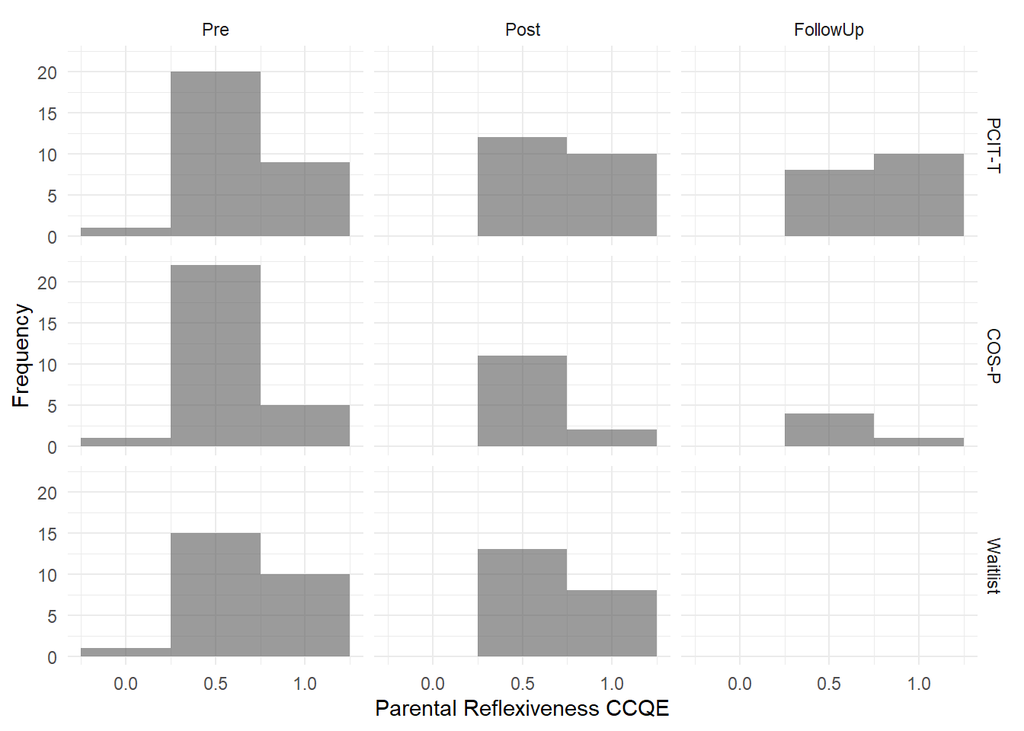

#### Model & Results

A linear mixed model with random effect for individual and fixed effects of group, time and the interaction was run. ASD status was then entered into the model as a main effect and then the 3-way interaction. Estimated marginal means were obtained, and contrasts specified to test Hypothesis 1 and Hypothesis 2.

```
## fixed-effect model matrix is rank deficient so dropping 1 column / coefficient
```

```
## fixed-effect model matrix is rank deficient so dropping 3 columns / coefficients
```

```
## refitting model(s) with ML (instead of REML)
```

[output not shown]

Interesting! there may be an effect of ASD on the group* time interaction.

Ok, we have not had this hapen before. I think what I will do is proceed as previous, using the model with group*time and adjusting for the main effect of ASD case and present those results. Then, I will explore how the pattern of change over time for the 2 ASD groups differs.

Model3, the model with Group*Time, adjusted by ASD will be the model I use for Estimated Means.

```r
summary(result3)
```

```
## Linear mixed model fit by REML. t-tests use Satterthwaite's method [
## lmerModLmerTest]
## Formula: outcome ~ asdcase + group * time + (1 | id)
##    Data: dat
##
## REML criterion at convergence: -85
##
## Scaled residuals:
##     Min      1Q  Median      3Q     Max
## -2.6937 -0.4503  0.0013  0.4768  1.9645
##
## Random effects:
##  Groups   Name        Variance Std.Dev.
##  id       (Intercept) 0.01904  0.1380
##  Residual             0.01544  0.1243
## Number of obs: 163, groups:  id, 85
##
## Fixed effects:
##                Estimate Std. Error         df t value Pr(>|t|)
## (Intercept)   6.646e-01  3.537e-02  1.089e+02  18.789  < 2e-16 ***
## asdcase1     -9.959e-02  5.052e-02  7.278e+01  -1.971 0.052512 .
## group2       -2.087e-02  4.901e-02  1.121e+02  -0.426 0.671127
## group3        2.940e-05  4.966e-02  1.140e+02   0.001 0.999529
## time2         1.197e-01  3.625e-02  7.794e+01   3.301 0.001455 **
## time3         1.510e-01  3.908e-02  7.929e+01   3.865 0.000226 ***
## group2:time2 -1.269e-01  5.835e-02  8.457e+01  -2.175 0.032385 *
## group3:time2 -8.285e-02  5.254e-02  7.847e+01  -1.577 0.118851
## group2:time3 -1.054e-01  7.873e-02  8.638e+01  -1.339 0.184148
## ---
## Signif. codes:  0 '***' 0.001 '**' 0.01 '*' 0.05 '.' 0.1 ' ' 1
##
## Correlation of Fixed Effects:
##             (Intr) asdcs1 group2 group3 time2  time3  grp2:2 grp3:2
## asdcase1    -0.286
## group2      -0.690  0.096
## group3      -0.668  0.050  0.477
## time2       -0.397 -0.014  0.288  0.285
## time3       -0.363 -0.032  0.266  0.264  0.422
## group2:tim2  0.252 -0.009 -0.374 -0.178 -0.621 -0.262
## group3:tim2  0.267  0.036 -0.196 -0.430 -0.690 -0.292  0.428
## group2:tim3  0.176  0.031 -0.273 -0.130 -0.210 -0.497  0.326  0.145
## fit warnings:
## fixed-effect model matrix is rank deficient so dropping 1 column / coefficient
```

#### Estimated Means & Change

Estimated means for each Treatment and Time (adjusted by ASD status) are presented. In addition, within-group change between time points is presented with 95% CIs.

##### Group mean difference at each timepoint

Effect sizes all calculated by the pooled T1 SD of the outcome. Adjusted p-value from Bonferroni correction.

Group Differences at Each Time Point

| Group Difference | Time | Mean | SE | t | p | adj p | Lower CL | Upper CL | Effect Size | Lower CL | Upper CL |
| --- | --- | --- | --- | --- | --- | --- | --- | --- | --- | --- | --- |
| 1 - 2 | 1 | 0.021 | 0.049 | 0.426 | 0.905 | 1.000 | -0.096 | 0.137 | 0.111 | -0.428 | 0.569 |
| 1 - 3 | 1 | 0.000 | 0.050 | -0.001 | 1.000 | 1.000 | -0.118 | 0.118 | 0.000 | -0.514 | 0.473 |
| 2 - 3 | 1 | -0.021 | 0.050 | -0.414 | 0.910 | 1.000 | -0.141 | 0.099 | -0.111 | -0.636 | 0.420 |
| 1 - 2 | 2 | 0.148 | 0.061 | 2.432 | 0.043 | 0.049 | 0.004 | 0.292 | 0.784 | 0.145 | 1.444 |
| 1 - 3 | 2 | 0.083 | 0.055 | 1.514 | 0.288 | 0.397 | -0.047 | 0.212 | 0.439 | -0.225 | 0.989 |
| 2 - 3 | 2 | -0.065 | 0.061 | -1.058 | 0.542 | 0.876 | -0.210 | 0.080 | -0.345 | -1.019 | 0.273 |
| 1 - 2 | 3 | 0.126 | 0.081 | 1.560 | 0.266 | 0.363 | -0.065 | 0.318 | 0.669 | -0.194 | 1.497 |
| 1 - 3 | 3 | NA | NA | NA | NA | NA | NA | NA | NA | NA | NA |
| 2 - 3 | 3 | NA | NA | NA | NA | NA | NA | NA | NA | NA | NA |

* Effect size scaled by pooled T1 SD  
† ES 95% Bootstrapped Percentile CI limits  
‡ If you want a positive ES (and it is calculated as negative), be sure to switch the signs and positions of the lower and upper CIs.

##### Change within each group

Within-Group Change and Effect Sizes

| Change | Group | Mean | SE | t | p | adj p | Lower CL | Upper CL | Effect Size | Lower CL | Upper CL |
| --- | --- | --- | --- | --- | --- | --- | --- | --- | --- | --- | --- |
| 1 - 2 | 1 | -0.120 | 0.036 | -3.295 | 0.004 | 0.004 | -0.206 | -0.033 | -0.634 | -1.028 | -0.289 |
| 1 - 3 | 1 | -0.151 | 0.039 | -3.855 | 0.001 | 0.001 | -0.245 | -0.058 | -0.801 | -1.221 | -0.391 |
| 2 - 3 | 1 | -0.031 | 0.041 | -0.773 | 0.721 | 1.000 | -0.128 | 0.066 | -0.166 | -0.575 | 0.240 |
| 1 - 2 | 2 | 0.007 | 0.046 | 0.158 | 0.986 | 1.000 | -0.102 | 0.117 | 0.039 | -0.509 | 0.533 |
| 1 - 3 | 2 | -0.046 | 0.069 | -0.665 | 0.785 | 1.000 | -0.209 | 0.118 | -0.242 | -0.956 | 0.477 |
| 2 - 3 | 2 | -0.053 | 0.071 | -0.749 | 0.735 | 1.000 | -0.221 | 0.116 | -0.281 | -0.988 | 0.393 |
| 1 - 2 | 3 | -0.037 | 0.038 | -0.966 | 0.600 | 1.000 | -0.128 | 0.054 | -0.195 | -0.647 | 0.215 |
| 1 - 3 | 3 | NA | NA | NA | NA | NA | NA | NA | NA | NA | NA |
| 2 - 3 | 3 | NA | NA | NA | NA | NA | NA | NA | NA | NA | NA |

* Effect size scaled by pooled T1 SD  
† ES 95% Bootstrapped Percentile CI limits  
‡ If you want a positive ES (and it is calculated as negative), be sure to switch the signs and positions of the lower and upper CIs.

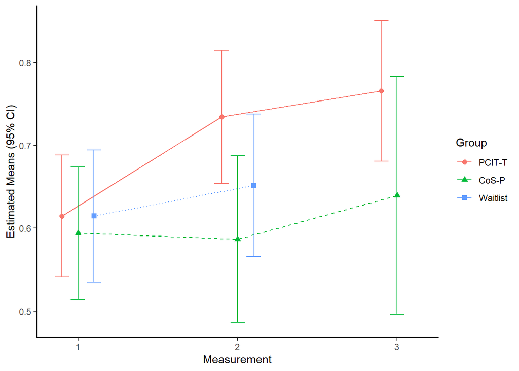

#### Hypothesis 1

We hypothesize that from baseline (‘T1’) to post-treatment/waitlist (‘T2’) there will be a gradient effect, whereby parent-child dyads who receive PCIT-T will show the greatest gains and parent-child dyads who receive no treatment will show the least gains. For the outcome, then, the null hypothesis is:

$H_0: \text {mean change}(\text{PCIT-T}) = \text {mean change}(\text{CoS-P}) = \text {mean change}(\text{Waitlist})$ $H_A: \text {mean change}(\text{PCIT-T}) > \text {mean change}(\text{CoS-P}) > \text {mean change}(\text{Waitlist})$

This is a joint hypothesis test.

First, confirming that the ordering of the means is as hypothesized:

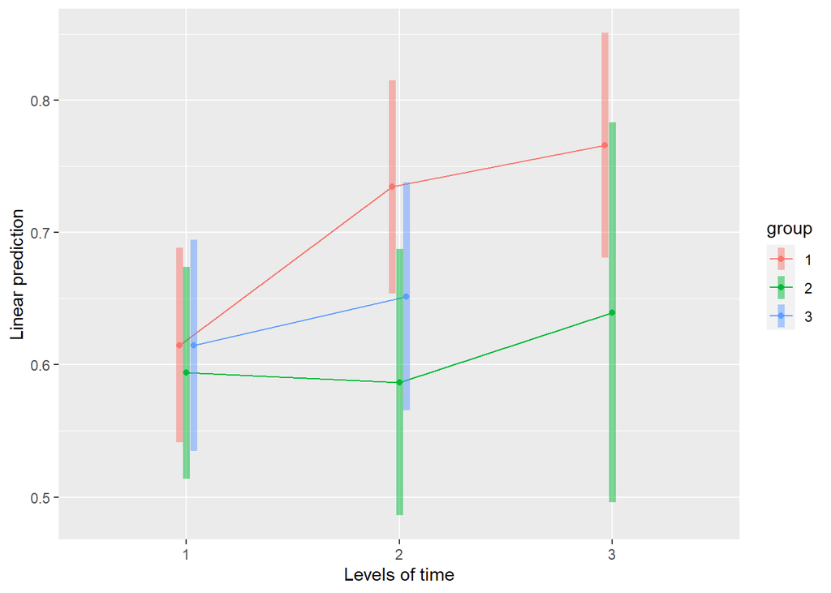

```
## group = 1:
##  contrast estimate     SE   df t.ratio p.value
##  1 - 2    -0.11967 0.0363 81.8  -3.295  0.0041
##  1 - 3    -0.15104 0.0392 83.1  -3.855  0.0007
##  2 - 3    -0.03138 0.0406 78.0  -0.773  0.7209
##
## group = 2:
##  contrast estimate     SE   df t.ratio p.value
##  1 - 2     0.00727 0.0459 92.7   0.158  0.9863
##  1 - 3    -0.04564 0.0687 92.7  -0.665  0.7846
##  2 - 3    -0.05291 0.0706 83.4  -0.749  0.7349
##
## group = 3:
##  contrast estimate     SE   df t.ratio p.value
##  1 - 2    -0.03682 0.0381 82.9  -0.966  0.6001
##  1 - 3      nonEst     NA   NA      NA      NA
##  2 - 3      nonEst     NA   NA      NA      NA
##
## Results are averaged over the levels of: asdcase
## Degrees-of-freedom method: kenward-roger
## P value adjustment: tukey method for comparing a family of 3 estimates
```

PCITT increases from baseline to post (-.120) while there is minimal change in COSP and Waitlist.

```
##   (Intercept) asdcase1 group2 group3 time2 time3 group2:time2 group3:time2
## 1           0        0      0      0     0     0           -1            0
## 2           0        0      0      0     0     1            0            1
##   group2:time3
## 1            0
## 2            0
```

```
##
##   General Linear Hypotheses
##
## Linear Hypotheses:
##        Estimate
## 1 == 0  0.12693
## 2 == 0  0.06819
##
## Global Test:
##       F DF1 DF2  Pr(>F)
## 1 3.899   2 152 0.02232
```

#### Hypothesis 2

There will be a gradient of size of change from T2 to T3 such that the change in the PCIT-T group > the change in the CoS-P group. This isn’t really a gradient; it’s just 1 hypothesis.

First, the change in PCITT and COSP from time 2 to time 3:

```
## group = 1:
##  contrast estimate     SE   df t.ratio p.value
##  1 - 2    -0.11967 0.0363 81.8  -3.295  0.0041
##  1 - 3    -0.15104 0.0392 83.1  -3.855  0.0007
##  2 - 3    -0.03138 0.0406 78.0  -0.773  0.7209
##
## group = 2:
##  contrast estimate     SE   df t.ratio p.value
##  1 - 2     0.00727 0.0459 92.7   0.158  0.9863
##  1 - 3    -0.04564 0.0687 92.7  -0.665  0.7846
##  2 - 3    -0.05291 0.0706 83.4  -0.749  0.7349
##
## group = 3:
##  contrast estimate     SE   df t.ratio p.value
##  1 - 2    -0.03682 0.0381 82.9  -0.966  0.6001
##  1 - 3      nonEst     NA   NA      NA      NA
##  2 - 3      nonEst     NA   NA      NA      NA
##
## Results are averaged over the levels of: asdcase
## Degrees-of-freedom method: kenward-roger
## P value adjustment: tukey method for comparing a family of 3 estimates
```

```
##
##   Simultaneous Tests for General Linear Hypotheses
##
## Fit: lmer(formula = outcome ~ asdcase + group * time + (1 | id), data = dat)
##
## Linear Hypotheses:
##        Estimate Std. Error z value Pr(>|z|)
## 1 == 0  0.02153    0.08128   0.265    0.791
## (Adjusted p values reported -- single-step method)
```

p>0.05.

#### Residuals

Assumptions of the model are met.

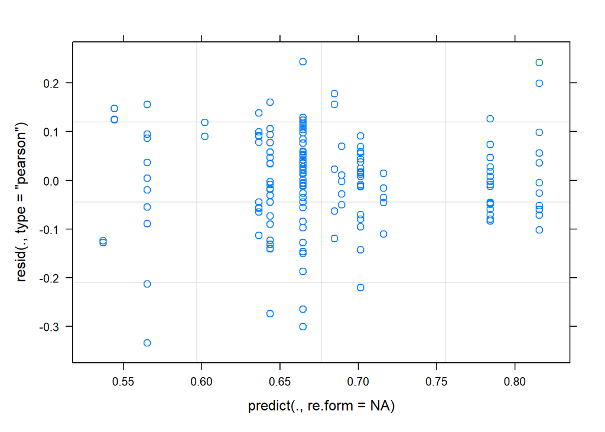

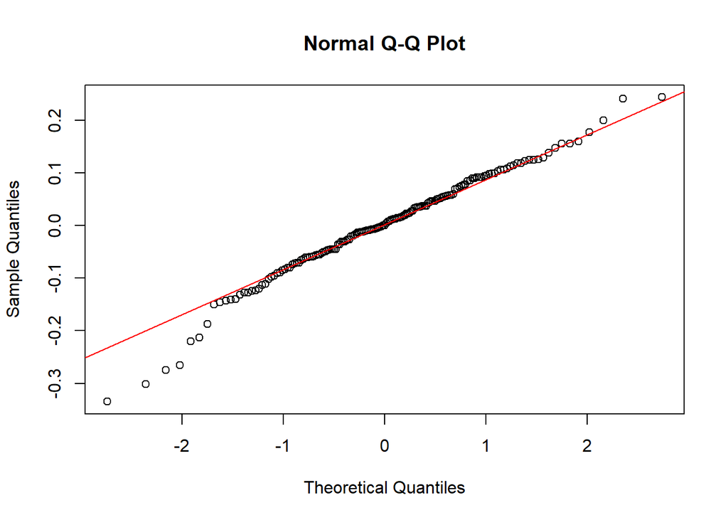

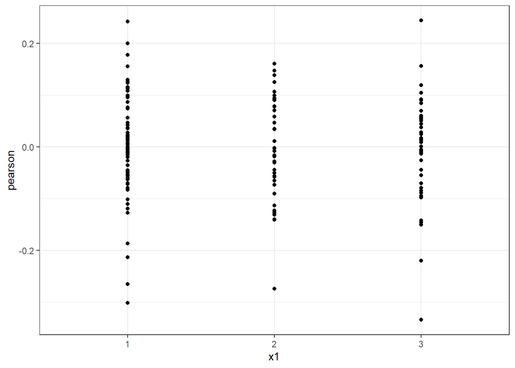

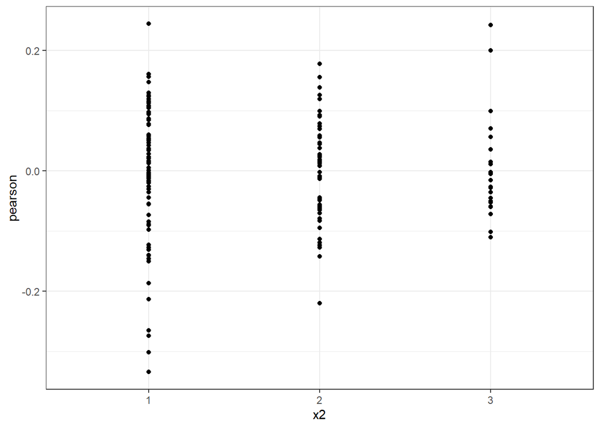

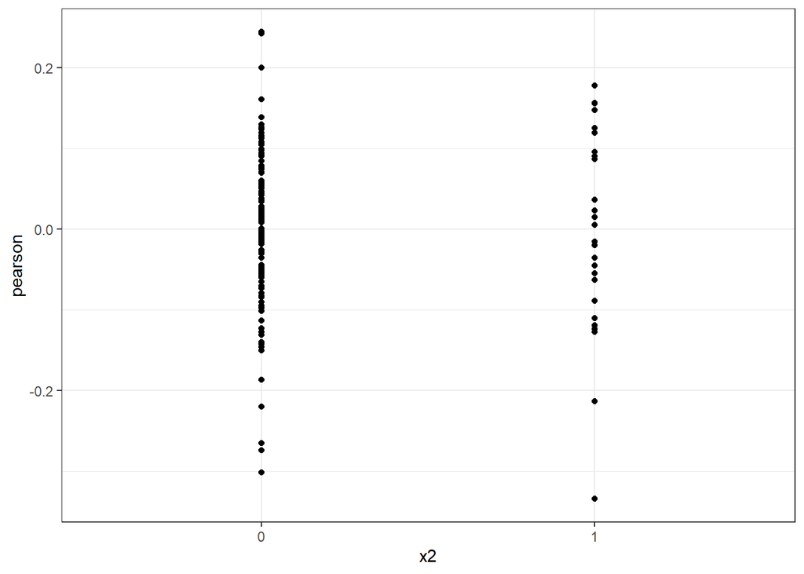

#### ASD Case Interaction

In the above model, the interaction between ASD, group and time was significant, indicating that the pattern of change over time is different for those with and without an ASD diagnosis.

Now, the thing to be careful with here is that there are relatively few ASD cases, and by the post time point, there are only 2 in the COSP group.

```r
desctable %>%
           kbl(digits=3, caption="Raw Data") %>%
           kable_minimal()
```

Raw Data

| asdcase | group | time | n | mean | sd | median | min | max |
| --- | --- | --- | --- | --- | --- | --- | --- | --- |
| 0 | 1 | 1 | 24 | 1.982 | 0.360 | 2.000 | 1.167 | 2.556 |
| 0 | 1 | 2 | 17 | 2.157 | 0.256 | 2.111 | 1.833 | 2.556 |
| 0 | 1 | 3 | 13 | 2.295 | 0.352 | 2.167 | 1.667 | 2.889 |
| 0 | 2 | 1 | 25 | 1.891 | 0.350 | 1.833 | 1.222 | 2.722 |
| 0 | 2 | 2 | 11 | 1.955 | 0.275 | 1.833 | 1.667 | 2.556 |
| 0 | 2 | 3 | 5 | 2.033 | 0.224 | 1.944 | 1.833 | 2.389 |
| 0 | 3 | 1 | 22 | 2.021 | 0.335 | 2.056 | 1.389 | 2.556 |
| 0 | 3 | 2 | 19 | 2.020 | 0.303 | 2.056 | 1.444 | 2.611 |
| 0 | 3 | 3 | 0 | NaN | NA | NA | Inf | -Inf |
| 1 | 1 | 1 | 6 | 1.769 | 0.319 | 1.778 | 1.333 | 2.278 |
| 1 | 1 | 2 | 5 | 2.067 | 0.390 | 2.222 | 1.500 | 2.389 |
| 1 | 1 | 3 | 5 | 1.967 | 0.288 | 1.889 | 1.667 | 2.444 |
| 1 | 2 | 1 | 3 | 2.093 | 0.170 | 2.056 | 1.944 | 2.278 |
| 1 | 2 | 2 | 2 | 1.528 | 0.039 | 1.528 | 1.500 | 1.556 |
| 1 | 2 | 3 | 0 | NaN | NA | NA | Inf | -Inf |
| 1 | 3 | 1 | 4 | 1.722 | 0.855 | 1.583 | 0.833 | 2.889 |
| 1 | 3 | 2 | 2 | 2.444 | 0.629 | 2.444 | 2.000 | 2.889 |
| 1 | 3 | 3 | 0 | NaN | NA | NA | Inf | -Inf |

Let’s look at the ANOVA table again

[output not shown]

and the model results

```r
summary(result4)
```

```
## Linear mixed model fit by REML. t-tests use Satterthwaite's method [
## lmerModLmerTest]
## Formula: outcome ~ asdcase * group * time + (1 | id)
##    Data: dat
##
## REML criterion at convergence: -82.4
##
## Scaled residuals:
##      Min       1Q   Median       3Q      Max
## -2.47614 -0.43150  0.05646  0.45848  2.19170
##
## Random effects:
##  Groups   Name        Variance Std.Dev.
##  id       (Intercept) 0.01814  0.1347
##  Residual             0.01473  0.1214
## Number of obs: 163, groups:  id, 85
##
## Fixed effects:
##                        Estimate Std. Error        df t value Pr(>|t|)
## (Intercept)             0.66673    0.03701 109.63090  18.017  < 2e-16 ***
## asdcase1               -0.11016    0.08275 109.63090  -1.331 0.185868
## group2                 -0.04603    0.05181 109.63090  -0.888 0.376234
## group3                  0.01911    0.05333 111.45397   0.358 0.720700
## time2                   0.10882    0.04013  74.89295   2.712 0.008300 **
## time3                   0.16721    0.04442  76.71503   3.764 0.000325 ***
## asdcase1:group2         0.22570    0.13827 109.63090   1.632 0.105473
## asdcase1:group3        -0.12636    0.12860 109.94430  -0.983 0.327976
## asdcase1:time2          0.04703    0.08534  72.58578   0.551 0.583235
## asdcase1:time3         -0.05339    0.08744  73.14598  -0.611 0.543347
## group2:time2           -0.07026    0.06287  81.18000  -1.117 0.267090
## group3:time2           -0.09933    0.05619  74.48106  -1.768 0.081189 .
## group2:time3           -0.09861    0.08058  82.63928  -1.224 0.224552
## asdcase1:group2:time2  -0.37420    0.15250  76.54265  -2.454 0.016410 *
## asdcase1:group3:time2   0.19482    0.14802  78.94513   1.316 0.191918
## ---
## Signif. codes:  0 '***' 0.001 '**' 0.01 '*' 0.05 '.' 0.1 ' ' 1
```

```
##
## Correlation matrix not shown by default, as p = 15 > 12.
## Use print(x, correlation=TRUE)  or
##     vcov(x)        if you need it
```

```
## fit warnings:
## fixed-effect model matrix is rank deficient so dropping 3 columns / coefficients
```

Here is what the pattern of means looks like:

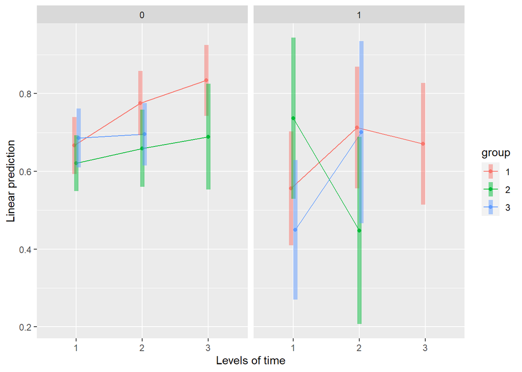

First, we can see that the CIs for the ASD group are much wider, which makes sense because there are so few kids in that group.

Next, we can see that the patterns for the PCITT and Waitlist groups are similar; it’s really the COSP group (green) that is quite different. My guess is it is this difference that is driving the p-value for the 3-way interaction. Given that the there are only 2 people in the COSP group at Post, I would not put too much faith in this as an effect that would remain if there were a larger sample.

[output not shown]